# Eyeballing Warp

JH

21/04/2015

# Background

SWI is planning to trial the current set of log segregation models, probably at Tenon. Two batches of logs will be selected based on predicted warp out-turn. These will then be batch sawn and the warp of the resulting lumber evaluated.

No intention to track board to individual logs (let alone position within log).

In total the project has a budget of only $50k, perhaps $15k could be assigned to measuring lumber (???). Warp evaluation also need to be completed in a reasonable amount of time (i.e. hours/days not weeks).

Will the lumber be predominantly 90x40?

How will the boards be conditioned prior to warp measurement? How will they be stored?

How will boards be evaluated? What will be measured? How?

Would a eyeball warp classification (e.g. straight, acceptable, unacceptable) suffice?

How big can the batch size be? i.e. how many logs can we have in the stable and unstable batches? Any point in having different numbers of logs in each batch?

Eyeballing to rank all logs vs eyeballing to rank extreme log classes

Jonathan will have a look at the KPP and Hyne data to see if categorising boards into simple warp categories will allow differences to be detected between the batches.

How is lumber quality ranked operationally at the mill? % of degrade by defect type? Overall reject rate only? QC of sample packs?

What is required of a warp measurement? Permit reliably testing for significant differences in the distribution of warp from the super-stable and super-unstable batches. Interested in reject rates more than mean values.

Selecting for what log characteristic (e.g. average crook, 75%ile ABC, etc) will lead to obervable differences in recovered product quality?

# Goals

1. How many good and bad logs, or how large a pile of boards, will be required for different prediction cutoffs to produce measurably different product piles in Tenon trial?
2. If rather than measuring warp, boards were categorized as straight, moderately or severely warped (either individually or jointly for bow, crook and twist) then would this suffice to test log-level segregation?

# The ‘Eyeballing’ Option

# Baseline

## Joe90

Joe90 produces:

- board weight, volume and hence density
- SWV and hence dynamic MOE
- warp profiles and summary measures
- surface imagery for defect analysis

```r
library(RODBC)
ch = odbcConnect("Joe90")
J = sqlQuery(ch, "select * from scans")
summary(as.numeric(diff(J$scantime)))
```

```
##     Min.  1st Qu.   Median     Mean  3rd Qu.     Max.
## -7282000       82       95    14040      117 24290000
```

Max throughput 40 boards/hr. Typically expect 10 boards/log. If measured at a reasonable rate (e.g. $30/hr) $15k => 500 hrs => 20k boards => 2000 logs => batch size of 1000 logs. BUT would take 10 weeks to measure boards!

At Scion actual rate ($136/hr RP; $156/hr JL) and a less optimistic throughput rate of 30 boards/hr batch size reduces to 150 logs but only 2 weeks to measure.

## Manual

Minimum of two people required. Similar time per board as Joe90 if both warp and SWV required. Operator classifiers (pith, knots etc) easily incorporated with minimal time penalty. No warp profile data. Total hourly rate between $60 and $200. So feasible batch size similar to Joe90.

Additional advantage of the eyeballing method is that it is easy to parallelize. More people should lead to poportionally greater throughput (leaving aside issues arising from differences between operators).

## Inline Lumber Scanners

Pros:

- Fast.
- Sometimes matched with MC measurement.

Cons:

- Limited availibilty. Only exist in some mills.
- Requires interrupting normal operation. Sometimes hard/impossible to recover boards after scanner.
- Accuracy uncertain.

## Other

Currently no other options exist. However, cheap, portable high throughput warp measurement with reasonable accuracy appears feasible (e.g by using 3d-cameras and SLAM). Before committing to developing such though some questions need answering:

- worth trying to accurately measure warp if mc state unknown?
- throughput substantially greater than existing options? (e.g. joescan @ 1min/board)
- low enough capital cost to scale up by having more devices?
- how would board transport be achieved? needs to be universally available or allow many options to permit use in a variety of contexts.

# Approach

Inter-related issues affecting interpretation of an experiment such as is proposed at Tenon:

1. Imprecision of eyeballing method.
2. ‘Good’ and ‘bad’ logs contain a mixture of ‘good’ and ‘bad’ boards
3. Precision of prediction models.

The point of the trial is to test the latter, but we don’t want to be misled by the either of the former.

Lets start by assuming a ‘perfect’ predictive model. The results from this can then be used to determine experimental configurations (measurement precision, number of logs, log selection criteria, etc) that should be sufficient to distinguish differences bewteen ‘good’ and ‘bad’ logs.

Ideally a good experimental configuration would:

- require as few logs (and hence boards) as possible in each tail (i.e. ‘good’ and ‘bad’ logs)
- select logs beyond as high a cutoff (%ile) as possible, the best case being to divide down the middle. Put another way, the broader the tail the better.
- tolerate imprecise classification of boards (i.e. lousy eyeballing)

## Assumptions

- boards will be 90x40
- Hyne data applicable to CNI

# Analysis & Results

## Dataset

```r
library(RODBC)
library(lattice)
library(ggplot2)
library(gridExtra)
summarise.boards <- function(L,B) {
  for (i in 1:nrow(L)) {
    ii=!is.na(B$log) & as.character(B$log)==as.character(L[i,"log"])
    L[i,"nboards"]=sum(ii)
    L[i,"bow_avg"]=mean(B$bow[!is.na(B$bow) & ii])
    L[i,"bow_50"]=median(B$bow[!is.na(B$bow) & ii])
    L[i,"bow_75"]=quantile(B$bow[!is.na(B$bow) & ii], 0.75)
    L[i,"crook_avg"]=mean(B$crook[!is.na(B$crook) & ii])
    L[i,"crook_50"]=median(B$crook[!is.na(B$crook) & ii])
    L[i,"crook_75"]=quantile(B$crook[!is.na(B$crook) & ii], 0.75)
    L[i,"twist_avg"]=mean(abs(B$twist[!is.na(B$twist) & ii]))
    L[i,"twist_50"]=median(abs(B$twist[!is.na(B$twist) & ii]))
    L[i,"twist_75"]=quantile(abs(B$twist[!is.na(B$twist) & ii]), 0.75)
    L[i,"wsbct_75"]=quantile(B$wsbct[!is.na(B$wsbct) & ii], 0.75)
  }
  return(L)
}
```

Hyne dataset:

```r
ch = odbcConnect('Hyne',uid='sa',pwd="password12")
B.hyne = sqlQuery(ch, "
             select
                SWILogNumber log,
                m.bow bow,
                m.crook crook,
                abs(asin(m.twist/(O_Width/10))*180) twist
             from (
                select flitchId, max(pith) pith, max(wane) wane, avg(swv) swv, avg(bow) bow, avg(crook) crook, avg(twist) twist
                from manualMeas group by flitchId
             ) m
             left join CHHBoards c on c.flitchId=m.flitchId
             left join (
                select flitchId, max(SWILogNumber) SWILogNumber
                from boardEndImages i, barcode_image bi, boardEndBarcodes b
                where flitchId is not null and i.id=bi.imageId and bi.barcodeId=b.id group by flitchId
             ) f on f.flitchId=m.flitchId
             where SWILogNumber is not null")
L.hyne = sqlQuery(ch, "select SWILogNumber log, volume vol from logs where SWILogNumber is not null and DateAndTime<'2014-08-31 00:00:00'")
```

KPP (LS.1.5) Dataset:

```r
ch = odbcConnect('LS15')
B.ls15 = sqlQuery(ch, "select ScionLogNumber log,
               abs(bowmid) bow,
               abs(crookmid) crook,
               abs(twisttot) twist
             from boards_logVlumber")
L.ls15 = sqlQuery(ch, "select ScionLogNumber log, volsed vol from logs_logVlumber")
```

```r
B = B.ls15
L = L.ls15
# Worst Scaled Bow, Crook or Twist
# normalize using WWPA.Cselect rules
B$wsbct = apply(as.matrix(data.frame(
  B$crook/25,
  B$bow/75,
  B$twist/3
  )),1,max,na.rm=TRUE)
L = summarise.boards(L,B)

for (p in c('crook_avg','wsbct_75')) {
L$log_rank = rank(L[,p])
for (i in 1:nrow(L)) {
  ii = B$log==L$log[i]
  B$log_rank[ii] = L$log_rank[i]
}
write.csv(B[,setdiff(names(B),c('log','wsbct'))], sprintf('/home/harrinjj/G/Projects/SWI/%s.csv',p), row.names=FALSE, quote=FALSE)
}
```

```r
summary(B)
```

```
##       log              bow               crook
##  Min.   :  1.00   Min.   : 0.00223   Min.   : 0.00114
##  1st Qu.: 28.00   1st Qu.: 3.46006   1st Qu.: 1.92761
##  Median : 52.00   Median : 7.46628   Median : 4.42416
##  Mean   : 51.41   Mean   :10.41917   Mean   : 6.45472
##  3rd Qu.: 76.00   3rd Qu.:14.18675   3rd Qu.: 8.53133
##  Max.   :100.00   Max.   :93.14220   Max.   :77.88680
##                   NA's   :2          NA's   :2
##      twist               wsbct         log_rank
##  Min.   : 0.000282   Min.   :-Inf   Min.   :  1.00
##  1st Qu.: 0.783218   1st Qu.:   0   1st Qu.: 23.00
##  Median : 1.698160   Median :   1   Median : 46.00
##  Mean   : 2.221302   Mean   :-Inf   Mean   : 48.17
##  3rd Qu.: 3.022895   3rd Qu.:   1   3rd Qu.: 73.00
##  Max.   :18.354601   Max.   :   6   Max.   :100.00
##  NA's   :2
```

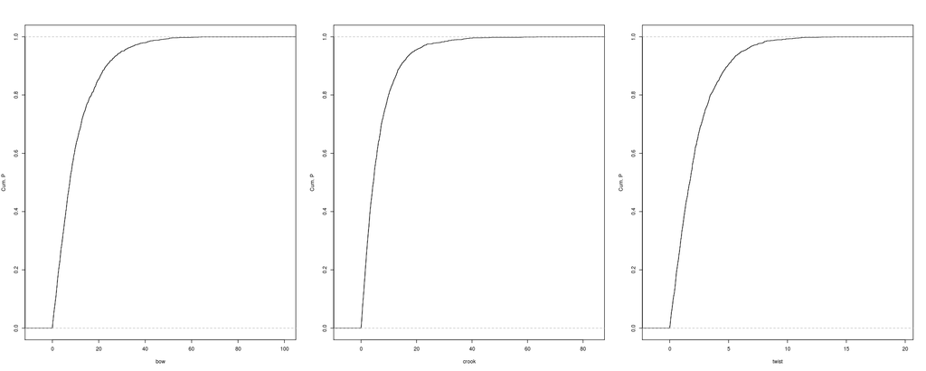

```r
par(mfcol=c(1,3))
for (p in c('bow','crook','twist')) {
  plot(ecdf(B[,p]), main="", xlab=p, ylab="Cum. P")
}
```

## Simulation

Now go run ‘eyeballing.py’. Run 1000 experiments, with 50 to 1000 boards in either tail.

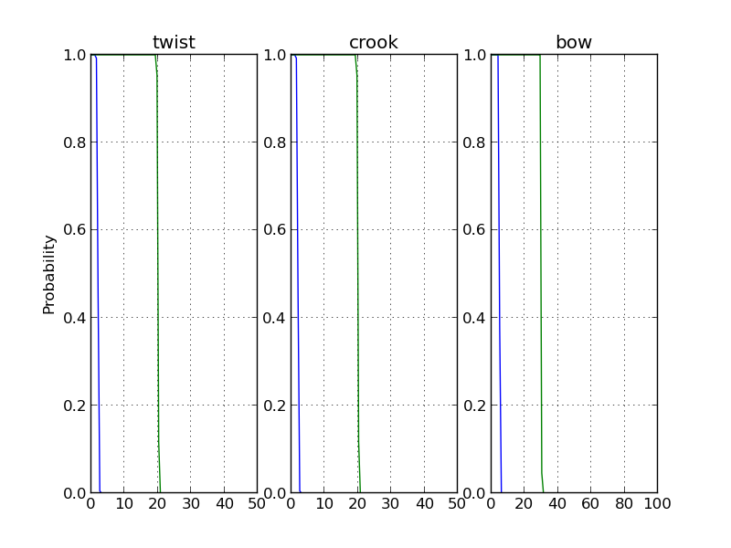

.

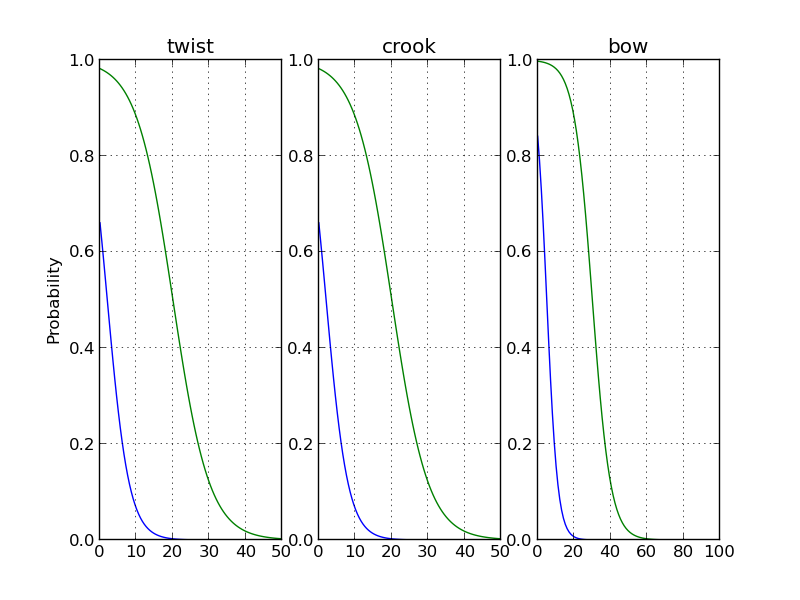

.

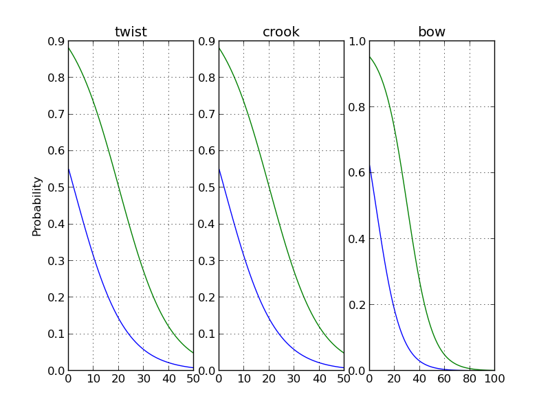

.

```r
plot.results <- function(R) {
  for (k in c('prop','tail','class','pctile','obs')) {
    R[,k] = factor(R[,k])
  }
  levels(R$pctile) <- paste(levels(R$pctile),'%ile',sep="")
  plots = c()
  for (obs in levels(R$obs)) {
      plots <- c(plots, list(
                    ggplot(data=R[R$obs==obs,], aes(x = class, y = count, fill = tail))
                    + geom_boxplot()
                    + facet_grid(prop~pctile)
                    + ggtitle(paste(obs, 'observer'))#; nboards=',nboards,'; nexpts=',nexpts))
                     + theme(legend.position="none")
                    )
                 )
  }
  #browser()
  do.call(grid.arrange,
                c(plots,
                  list(ncol=length(levels(R$obs)))))
}
```

### Select logs based on crook_avg

#### 50 boards

```r
R = read.csv('/home/harrinjj/G/Projects/SWI/crook_avg.csv50.csv')
```

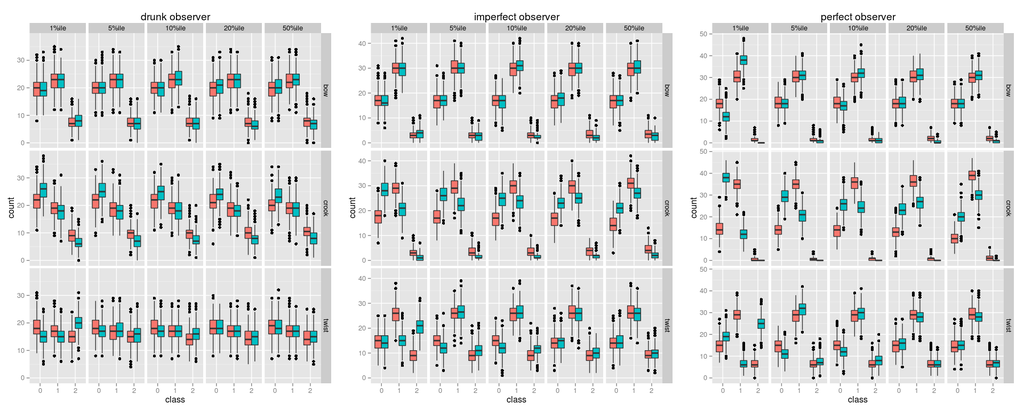

```r
plot.results(R)
```

#### 100 boards

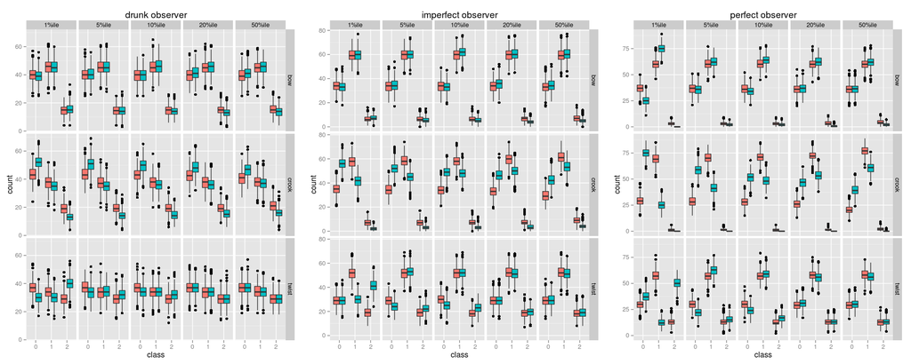

```r
R = read.csv('/home/harrinjj/G/Projects/SWI/crook_avg.csv100.csv')
plot.results(R)
```

#### 500 boards

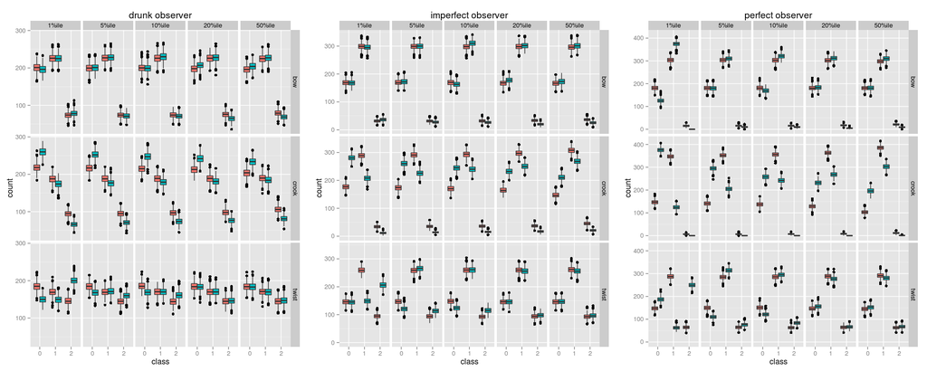

```r
R = read.csv('/home/harrinjj/G/Projects/SWI/crook_avg.csv500.csv')
plot.results(R)
```

#### 1000 boards

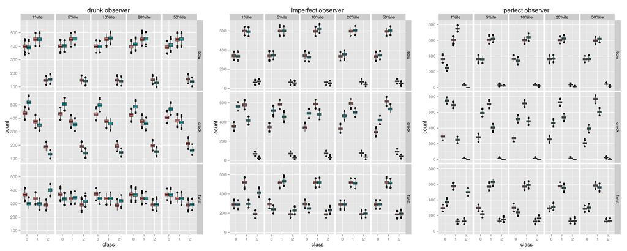

```r
R = read.csv('/home/harrinjj/G/Projects/SWI/crook_avg.csv1000.csv')
plot.results(R)
```

### Select logs based on 75%ile WSBCT

#### 50 boards

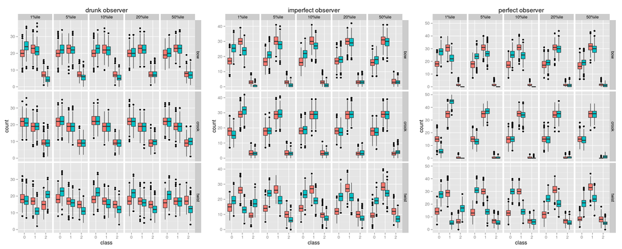

```r
R = read.csv('/home/harrinjj/G/Projects/SWI/wsbct_75.csv50.csv')
plot.results(R)
```

#### 100 boards

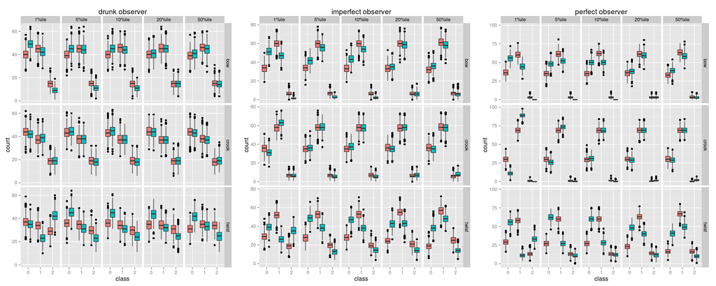

```r
R = read.csv('/home/harrinjj/G/Projects/SWI/wsbct_75.csv100.csv')
plot.results(R)
```

#### 500 boards

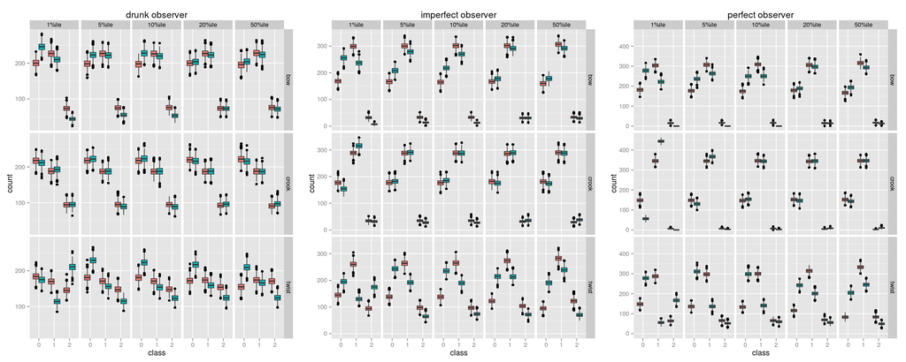

```r
R = read.csv('/home/harrinjj/G/Projects/SWI/wsbct_75.csv500.csv')
plot.results(R)
```

#### 1000 boards

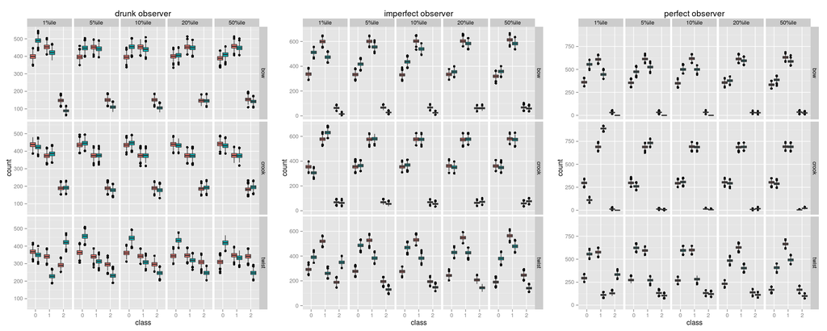

```r
R = read.csv('/home/harrinjj/G/Projects/SWI/wsbct_75.csv1000.csv')
plot.results(R)
```

# Conclusions

From the above it appears that eyeballing warp will not compromise an experiment that:

- selects the best and worst 10% of logs based on average crook
- has 500 boards in the good and bad piles
- with an observer whose performance is equal to or better than the ‘imperfect observer’

Other experimental configurations can be usefully considered based on the data presented above.

# Next

- cheap access to joe90?
- a cheap SLAM based approach (3D camera + conveyor/roller table)
- for a reasonable experimental config (e.g 500 boards per tail, 10%ile segregation for crook_avg, imperfect observer) how bad can the predictive model be before no statistical significant differences can be detected between good and bad logs?
- Rerun the above using the LS.1.5 dataset. DONE results (and conclusions) based on either dataset appear similar.
- Rerun the above using ABC and Stan’s model